# Beers And Breweries

Analysis of US Beers and Breweries

# *Which States Have Breweries?*

[figure not shown]

### It would seem all states have at least 1 brewery in them. That being said, the state with the most amount of breweries was Colorado with 47 breweries in total. The state with the least was a 4 way tie between West Virginia, DC, and both of the Dakotas as they only had 1.

# *Which Beer Has The Most Breweries?*

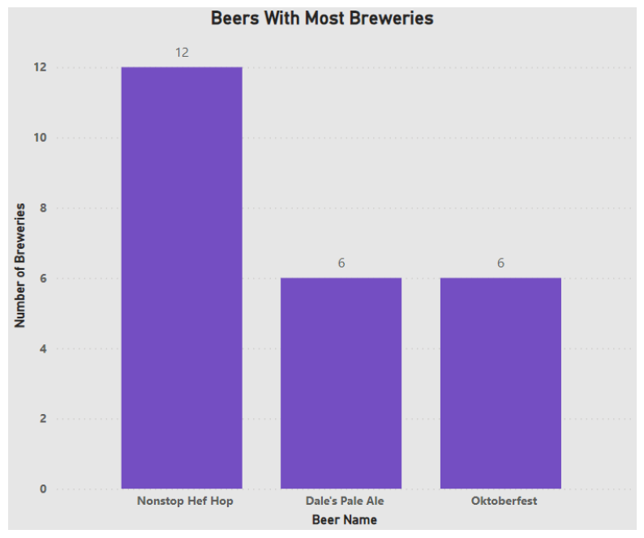

### "Nonstop Hef Hop" had 12 breweries, double the amount of the beers in 2nd place which were "Dale's Pale Ale" and "Oktoberfest"

# *What Type of Beer Has The Most Breweries?*

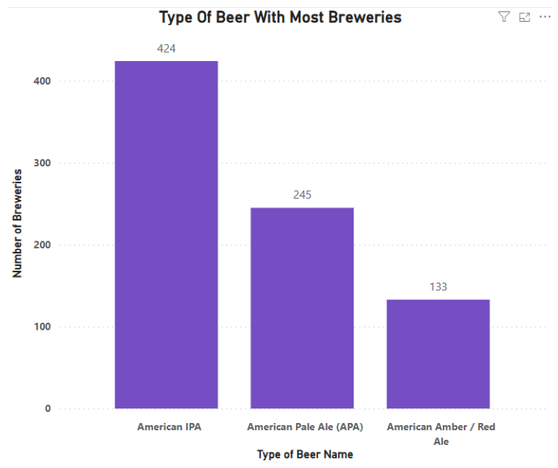

### American IPAs had the most amount of breweries with 424 total while American Pale Ales had 245 and American Amber/Red Ale had 133.

# *Conclusion*

## The state with the most breweries was Colorado and the most popular beer type was the American IPA. If unafraid of competition, I'd recommend to open up an American IPA brewery in Colorado. There are clear indications of customer demand for American IPAs and Colorado has shown to be a high concentration of breweries.